# RLohiya Final Project

Ritesh Lohiya

December 7, 2018

# IS 605 FUNDAMENTALS OF COMPUTATIONAL MATHEMATICS

```r
#Load libraries
suppressMessages(suppressWarnings(library(readr)))
suppressMessages(suppressWarnings(library(kableExtra)))
suppressMessages(suppressWarnings(library(tidyverse)))
suppressMessages(suppressWarnings(library(knitr)))
suppressMessages(suppressWarnings(library(psych)))
suppressMessages(suppressWarnings(library(gridExtra)))
suppressMessages(suppressWarnings(library(usdm)))
suppressMessages(suppressWarnings(library(mice)))
suppressMessages(suppressWarnings(library(ggiraph)))
suppressMessages(suppressWarnings(library(cowplot)))
suppressMessages(suppressWarnings(library(reshape2)))
suppressMessages(suppressWarnings(library(corrgram)))
suppressMessages(suppressWarnings(library(caTools)))
suppressMessages(suppressWarnings(library(caret)))
suppressMessages(suppressWarnings(library(ROCR)))
suppressMessages(suppressWarnings(library(pROC)))
suppressMessages(suppressWarnings(library(reshape2)))
suppressMessages(suppressWarnings(library(Amelia)))
suppressMessages(suppressWarnings(library(qqplotr)))
suppressMessages(suppressWarnings(library(moments)))
suppressMessages(suppressWarnings(library(car)))
suppressMessages(suppressWarnings(library(MASS)))
suppressMessages(suppressWarnings(library(geoR)))
suppressMessages(suppressWarnings(library(xtable)))
suppressMessages(suppressWarnings(library(plyr)))
suppressMessages(suppressWarnings(library(Hmisc)))
suppressMessages(suppressWarnings(library(corrplot)))
suppressMessages(suppressWarnings(library(PerformanceAnalytics)))
suppressMessages(suppressWarnings(library(ggpubr)))
suppressMessages(suppressWarnings(library(matrixcalc)))
suppressMessages(suppressWarnings(library(alr3)))
suppressMessages(suppressWarnings(library(bestglm)))
suppressMessages(suppressWarnings(library(car)))
suppressMessages(suppressWarnings(library(gridExtra)))
suppressMessages(suppressWarnings(library(scales)))
suppressMessages(suppressWarnings(library(Matrix)))
suppressMessages(suppressWarnings(library(Amelia)))
suppressMessages(suppressWarnings(library(mlr)))
suppressMessages(suppressWarnings(library(corrr)))
```

# Problem 1

## Pick one of the quantitative independent variables (Xi) from the data set below, and define that variable as X. Also, pick one of the dependent variables (Yi) below, and define that as Y.

```r
#download the files and then load them from storage
F1 <- read.csv("https://raw.githubusercontent.com/Riteshlohiya/Data605_Final_Project/master/F1.csv", stringsAsFactors = FALSE)
F1
```

```
##      Y1   Y2   Y3   Y4   X1   X2   X3   X4
## 1  20.3 20.8 28.4 20.2  9.3  7.4  9.5  9.3
## 2  19.1 14.6 21.5 18.6  4.1  6.4  3.7 12.4
## 3  19.3 18.0 20.8 22.6 22.4  8.5 11.7 19.9
## 4  20.9  7.3 22.2 11.4  9.1  9.5  7.4  6.9
## 5  22.0 19.4 21.6 23.6 15.8 11.8  5.3 -1.0
## 6  23.5 13.5 21.8 24.0  7.1  8.8  7.4 10.6
## 7  13.8 14.7 25.2 26.0 15.9  8.4  7.4  6.4
## 8  18.8 15.3 22.5 26.8  6.9  5.1  8.6 10.6
## 9  20.9 12.6 21.1 19.7 16.0 11.4  9.1  1.2
## 10 18.6 13.0 21.7 22.7  6.7 15.1 11.4  7.7
## 11 22.3 13.1 21.4 16.8  8.2 12.6  8.4 15.5
## 12 17.6 10.3 20.8 20.2 16.0  8.0  7.3  6.9
## 13 20.8 14.9 23.0 21.7  6.4 10.3 11.3 13.7
## 14 28.7 14.8 17.4 20.9 11.8 10.4  4.4  3.7
## 15 15.2 16.2 21.3 26.9  3.5  9.5  9.3  4.4
## 16 20.9 15.7 15.1 16.3 21.7  9.5 10.9 11.5
## 17 18.4 16.3 17.8 19.9 12.2 15.1 10.9  4.2
## 18 10.3 11.5 26.4 15.5  9.3  6.6  7.7 13.9
## 19 26.3 12.2 21.6 26.5  8.0 15.4  7.7 12.9
## 20 28.1 11.8 22.5 21.7  6.2  8.2 11.5  1.2
```

```r
#define X and Y.
X <- F1$X1
Y <- F1$Y1
```

## Probability.

Calculate as a minimum the below probabilities a through c. Assume the small letter “x” is estimated as the 3d quartile of the X variable, and the small letter “y” is estimated as the 1st quartile of the Y variable. Interpret the meaning of all probabilities.

```r
# get quartiles
#"x" is 3d quartile of X variable
#"y" is 2d quartile of X variable
summary(X)
```

```
##    Min. 1st Qu.  Median    Mean 3rd Qu.    Max.
##    3.50    6.85    9.20   10.83   15.82   22.40
```

```r
summary(Y)
```

```
##    Min. 1st Qu.  Median    Mean 3rd Qu.    Max.
##   10.30   18.55   20.55   20.29   22.07   28.70
```

The 3rd quartile of the X variable = 15.82 The 1st quartile of the Y variable = 18.55 So, x = 15.82 and y = 18.55

```r
x <- 15.82
y <- 18.55
```

```r
df<-data.frame(cbind(X,Y))
```

```r
PA_and_B <- nrow(subset(df, X > x & Y > y))/nrow(df)
PA <- nrow(subset(df, X > x))/nrow(df)
PB <- nrow(subset(df, Y > y))/nrow(df)
PC <- nrow(subset(df, X < x))/nrow(df)
PC_and_B <- nrow(subset(df, X < x & Y > y))/nrow(df)
```

## a. P(X>x | Y>y)

```r
# a. P(X>x | Y>y)
pA_given_B <- PA_and_B/PB
pA_given_B
```

```
## [1] 0.2
```

P(X>x | Y>y) = .2 or 20%, which means that there is 20% probablity of X>x or X will be greater than than it 3rd quartile value of 15.82 given that the Y is greater than its 1st quartile value of 18.55.

## b. P(X>x, Y>y)

```r
# b. P(X>x, Y>y)
PA_and_B
```

```
## [1] 0.15
```

P(X>x, Y>y) = .15 or 15%, which means that there is 15% probablity of X>x or X will be greater than than it 3rd quartile value of 15.82 while Y is greater than its 1st quartile value of 18.55.

## c. P(X < x | Y>y)

```r
# c. P(X<x|Y>y)
PC_given_B <- PC_and_B/PB
PC_given_B
```

```
## [1] 0.8
```

P(X < x|Y>y) = .8 or 80%, which means that there is 80% probablity of X < x or X will be smaller than than it 3rd quartile value of 15.82 given that the Y is greater than its 1st quartile value of 18.55.

## Table of Counts

```r
data_tbl <- as.data.frame(cbind.data.frame(X, Y, t1 = ifelse(X >
    x, ">1st quartile", "<=1st quartile"), Total = ifelse(Y > y, ">3d quartile",
    "<=3d quartile")))

tbl <- addmargins(table(data_tbl$t1, data_tbl$Total, dnn = c("X/Y")))
tbl
```

```
##                 NA
## X/Y              <=3d quartile >3d quartile Sum
##   <=1st quartile             3           12  15
##   >1st quartile              2            3   5
##   Sum                        5           15  20
```

## Does splitting the training data in this fashion make them independent? Let A be the new variable counting those observations above the 1st quartile for X, and let B be the new variable counting those observations above the 1st quartile for Y. Does P(AB)=P(A)P(B)? Check mathematically, and then evaluate by running a Chi Square test for association.

## Mathematical test:

```r
A <- tbl[2, 3]
A
```

```
## [1] 5
```

```r
B <- tbl[3, 2]
B
```

```
## [1] 15
```

```r
total <- tbl[3, 3]
total
```

```
## [1] 20
```

```r
A_AND_B <- tbl[2, 2]

# P(A)
PA <- A/total

# P(B)
PB <- B/total

# P(A INT B)
PA_INT_B <- A_AND_B/total


# P(A|B) = P(A INT B) / P(B)

PA_GIVEN_B <- PA_INT_B/PB

# P(A) * P(B)

PA_INTO_PB <- (PA * PB)

PA_GIVEN_B
```

```
## [1] 0.2
```

```r
PA_INTO_PB
```

```
## [1] 0.1875
```

## Chi Square test

```r
chisq.test(X,Y)
```

```
##
##  Pearson's Chi-squared test
##
## data:  X and Y
## X-squared = 306.67, df = 289, p-value = 0.2272
```

# Problem 2

## You are to register for Kaggle.com (free) and compete in the House Prices: Advanced Regression Techniques competition. https://www.kaggle.com/c/house-prices-advanced-regression-techniques . I want you to do the following.

```r
#download the train data
train <- read.csv("https://raw.githubusercontent.com/Riteshlohiya/Data605_Final_Project/master/train.csv", header = TRUE, stringsAsFactors = FALSE)
```

## Descriptive and Inferential Statistics.

Provide univariate descriptive statistics and appropriate plots for the training data set. Provide a scatterplot matrix for at least two of the independent variables and the dependent variable. Derive a correlation matrix for any THREE quantitative variables in the dataset. Test the hypotheses that the correlations between each pairwise set of variables is 0 and provide a 80% confidence interval. Discuss the meaning of your analysis. Would you be worried about familywise error? Why or why not?

Subsetting the dataset to get only the numeric columns.

First i will plot scatterplots for Gross living area and Sale price.

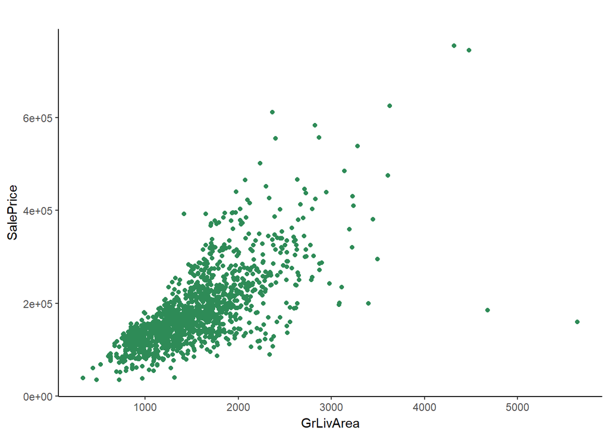

```r
ggplot(train, aes(x=GrLivArea, y=SalePrice)) + geom_jitter(color='seagreen4') + theme_classic() +
labs(title ='Scatter Plot of Gross living area vs Sale price') + theme(plot.title = element_text(hjust = 5000))
```

Scatter plot for Masonry veneer area in square feet and scale price

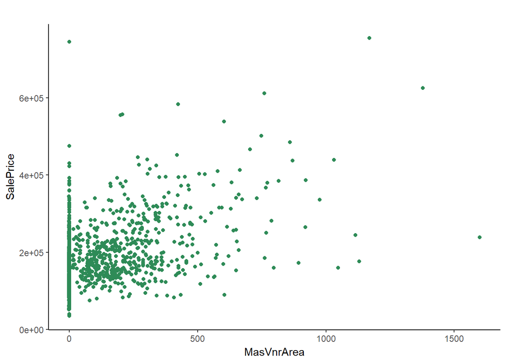

```r
ggplot(train, aes(x=MasVnrArea, y=SalePrice)) + geom_jitter(color='seagreen4') + theme_classic() +
labs(title ='Scatter Plot of Masonry veneer area vs Sale price') + theme(plot.title = element_text(hjust = 5000))
```

From the above scatter plots we can see that there is some kind of relation between the independent and dependent variables.

Lets now so some descriptive analysis on the available data.

## Descriptive statistics and plots

```r
num <- unlist(lapply(train, is.numeric))
train_num <- train[, num]
summary(train_num)
```

```
##        Id           MSSubClass     LotFrontage        LotArea
##  Min.   :   1.0   Min.   : 20.0   Min.   : 21.00   Min.   :  1300
##  1st Qu.: 365.8   1st Qu.: 20.0   1st Qu.: 59.00   1st Qu.:  7554
##  Median : 730.5   Median : 50.0   Median : 69.00   Median :  9478
##  Mean   : 730.5   Mean   : 56.9   Mean   : 70.05   Mean   : 10517
##  3rd Qu.:1095.2   3rd Qu.: 70.0   3rd Qu.: 80.00   3rd Qu.: 11602
##  Max.   :1460.0   Max.   :190.0   Max.   :313.00   Max.   :215245
##                                   NA's   :259
##   OverallQual      OverallCond      YearBuilt     YearRemodAdd
##  Min.   : 1.000   Min.   :1.000   Min.   :1872   Min.   :1950
##  1st Qu.: 5.000   1st Qu.:5.000   1st Qu.:1954   1st Qu.:1967
##  Median : 6.000   Median :5.000   Median :1973   Median :1994
##  Mean   : 6.099   Mean   :5.575   Mean   :1971   Mean   :1985
##  3rd Qu.: 7.000   3rd Qu.:6.000   3rd Qu.:2000   3rd Qu.:2004
##  Max.   :10.000   Max.   :9.000   Max.   :2010   Max.   :2010
##
##    MasVnrArea       BsmtFinSF1       BsmtFinSF2        BsmtUnfSF
##  Min.   :   0.0   Min.   :   0.0   Min.   :   0.00   Min.   :   0.0
##  1st Qu.:   0.0   1st Qu.:   0.0   1st Qu.:   0.00   1st Qu.: 223.0
##  Median :   0.0   Median : 383.5   Median :   0.00   Median : 477.5
##  Mean   : 103.7   Mean   : 443.6   Mean   :  46.55   Mean   : 567.2
##  3rd Qu.: 166.0   3rd Qu.: 712.2   3rd Qu.:   0.00   3rd Qu.: 808.0
##  Max.   :1600.0   Max.   :5644.0   Max.   :1474.00   Max.   :2336.0
##  NA's   :8
##   TotalBsmtSF       X1stFlrSF      X2ndFlrSF     LowQualFinSF
##  Min.   :   0.0   Min.   : 334   Min.   :   0   Min.   :  0.000
##  1st Qu.: 795.8   1st Qu.: 882   1st Qu.:   0   1st Qu.:  0.000
##  Median : 991.5   Median :1087   Median :   0   Median :  0.000
##  Mean   :1057.4   Mean   :1163   Mean   : 347   Mean   :  5.845
##  3rd Qu.:1298.2   3rd Qu.:1391   3rd Qu.: 728   3rd Qu.:  0.000
##  Max.   :6110.0   Max.   :4692   Max.   :2065   Max.   :572.000
##
##    GrLivArea     BsmtFullBath     BsmtHalfBath        FullBath
##  Min.   : 334   Min.   :0.0000   Min.   :0.00000   Min.   :0.000
##  1st Qu.:1130   1st Qu.:0.0000   1st Qu.:0.00000   1st Qu.:1.000
##  Median :1464   Median :0.0000   Median :0.00000   Median :2.000
##  Mean   :1515   Mean   :0.4253   Mean   :0.05753   Mean   :1.565
##  3rd Qu.:1777   3rd Qu.:1.0000   3rd Qu.:0.00000   3rd Qu.:2.000
##  Max.   :5642   Max.   :3.0000   Max.   :2.00000   Max.   :3.000
##
```

[output cut: 25 more lines]

```
##  Min.   :  0.00   Min.   :  0.000   Min.   :    0.00   Min.   : 1.000
##  1st Qu.:  0.00   1st Qu.:  0.000   1st Qu.:    0.00   1st Qu.: 5.000
##  Median :  0.00   Median :  0.000   Median :    0.00   Median : 6.000
##  Mean   : 15.06   Mean   :  2.759   Mean   :   43.49   Mean   : 6.322
##  3rd Qu.:  0.00   3rd Qu.:  0.000   3rd Qu.:    0.00   3rd Qu.: 8.000
##  Max.   :480.00   Max.   :738.000   Max.   :15500.00   Max.   :12.000
##
##      YrSold       SalePrice
##  Min.   :2006   Min.   : 34900
##  1st Qu.:2007   1st Qu.:129975
##  Median :2008   Median :163000
##  Mean   :2008   Mean   :180921
##  3rd Qu.:2009   3rd Qu.:214000
##  Max.   :2010   Max.   :755000
##
```